# SR_9_homework_CR

Christoph Rosa

2022-11-04

# Easy Questions

## Question 1

3. The proposal distribution has to be symmetric.

## Question 2

Gibbs-sampling uses *adaptive proposals*, meaning the proposed parameter distribution keeps “adapting” to the current parameter values.

One limitation of Gibbs-sampling is that it requires conjugal priors, which can become problematic in multilevel models. Also, when it comes to complex models with large numbers of parameters, even Gibbs-sampling algorithms become very inefficient.

## Question 3

HMC cannot handle discrete parameters. The reason is that the - much like the “royal vehicle” - the simulated particle that represents our parameter vector has to be able to “stop” at any given point, which is only possible if all the parameters that make up the vector are continuous.

## Question 4

In Stan, the term “n_eff” denotes an estimate of the effective number of independent samples from the posterior distribution.

The “raw” number of samples can be smaller than that, as the autocorrelation of Markov chains makes sequential samples somewhat dependent on each other; there are therefore less “effective” samples.

## Question 5

Rhat should approach 1.0 from above.

## Question 6

I’ll use the terrain data to sketch a good-looking trace plot.

```r
# loading packages and data
library(tidyverse)
library(rethinking)
library(rstanarm)
data(rugged)
set.seed(123)

# data wrangling
d <- rugged %>%
  mutate(loggdp = log(rgdppc_2000)) %>%
  filter(complete.cases(rgdppc_2000)) %>%
  mutate(lgdp_std = loggdp/mean(loggdp),
         rugged_std = rugged/max(rugged),
         cid = as.integer(ifelse(cont_africa == 1, 1, 2))) %>%
  select(lgdp_std, rugged_std, cid)

# creating chain
m <-
  ulam(
    alist(
      lgdp_std ~ dnorm(mu, sigma),
      mu <- a[cid] + b[cid] * (rugged_std - 0.215),
      a[cid] ~ dnorm(1, 0.1),
      b[cid] ~ dnorm(0, 0.3),
      sigma ~ dexp(1)
    ),
    data = d,
    chains = 4,
    cores = 4
  )
```

```
## Running MCMC with 4 parallel chains, with 1 thread(s) per chain...
##
## Chain 1 Iteration:   1 / 1000 [  0%]  (Warmup)
## Chain 1 Iteration: 100 / 1000 [ 10%]  (Warmup)
## Chain 1 Iteration: 200 / 1000 [ 20%]  (Warmup)
## Chain 1 Iteration: 300 / 1000 [ 30%]  (Warmup)
## Chain 1 Iteration: 400 / 1000 [ 40%]  (Warmup)
## Chain 1 Iteration: 500 / 1000 [ 50%]  (Warmup)
## Chain 1 Iteration: 501 / 1000 [ 50%]  (Sampling)
## Chain 1 Iteration: 600 / 1000 [ 60%]  (Sampling)
## Chain 1 Iteration: 700 / 1000 [ 70%]  (Sampling)
## Chain 1 Iteration: 800 / 1000 [ 80%]  (Sampling)
## Chain 1 Iteration: 900 / 1000 [ 90%]  (Sampling)
## Chain 1 Iteration: 1000 / 1000 [100%]  (Sampling)
## Chain 2 Iteration:   1 / 1000 [  0%]  (Warmup)
## Chain 2 Iteration: 100 / 1000 [ 10%]  (Warmup)
## Chain 2 Iteration: 200 / 1000 [ 20%]  (Warmup)
## Chain 2 Iteration: 300 / 1000 [ 30%]  (Warmup)
## Chain 2 Iteration: 400 / 1000 [ 40%]  (Warmup)
## Chain 2 Iteration: 500 / 1000 [ 50%]  (Warmup)
## Chain 2 Iteration: 501 / 1000 [ 50%]  (Sampling)
## Chain 2 Iteration: 600 / 1000 [ 60%]  (Sampling)
## Chain 2 Iteration: 700 / 1000 [ 70%]  (Sampling)
## Chain 2 Iteration: 800 / 1000 [ 80%]  (Sampling)
## Chain 2 Iteration: 900 / 1000 [ 90%]  (Sampling)
## Chain 2 Iteration: 1000 / 1000 [100%]  (Sampling)
## Chain 3 Iteration:   1 / 1000 [  0%]  (Warmup)
## Chain 3 Iteration: 100 / 1000 [ 10%]  (Warmup)
## Chain 3 Iteration: 200 / 1000 [ 20%]  (Warmup)
## Chain 3 Iteration: 300 / 1000 [ 30%]  (Warmup)
## Chain 3 Iteration: 400 / 1000 [ 40%]  (Warmup)
## Chain 3 Iteration: 500 / 1000 [ 50%]  (Warmup)
## Chain 3 Iteration: 501 / 1000 [ 50%]  (Sampling)
## Chain 3 Iteration: 600 / 1000 [ 60%]  (Sampling)
## Chain 3 Iteration: 700 / 1000 [ 70%]  (Sampling)
## Chain 3 Iteration: 800 / 1000 [ 80%]  (Sampling)
## Chain 3 Iteration: 900 / 1000 [ 90%]  (Sampling)
## Chain 4 Iteration:   1 / 1000 [  0%]  (Warmup)
## Chain 4 Iteration: 100 / 1000 [ 10%]  (Warmup)
## Chain 4 Iteration: 200 / 1000 [ 20%]  (Warmup)
## Chain 4 Iteration: 300 / 1000 [ 30%]  (Warmup)
## Chain 4 Iteration: 400 / 1000 [ 40%]  (Warmup)
## Chain 4 Iteration: 500 / 1000 [ 50%]  (Warmup)
## Chain 4 Iteration: 501 / 1000 [ 50%]  (Sampling)
## Chain 1 finished in 0.1 seconds.
## Chain 2 finished in 0.1 seconds.
## Chain 3 Iteration: 1000 / 1000 [100%]  (Sampling)
## Chain 3 finished in 0.1 seconds.
## Chain 4 Iteration: 600 / 1000 [ 60%]  (Sampling)
## Chain 4 Iteration: 700 / 1000 [ 70%]  (Sampling)
## Chain 4 Iteration: 800 / 1000 [ 80%]  (Sampling)
## Chain 4 Iteration: 900 / 1000 [ 90%]  (Sampling)
## Chain 4 Iteration: 1000 / 1000 [100%]  (Sampling)
## Chain 4 finished in 0.1 seconds.
##
## All 4 chains finished successfully.
## Mean chain execution time: 0.1 seconds.
## Total execution time: 1.5 seconds.
```

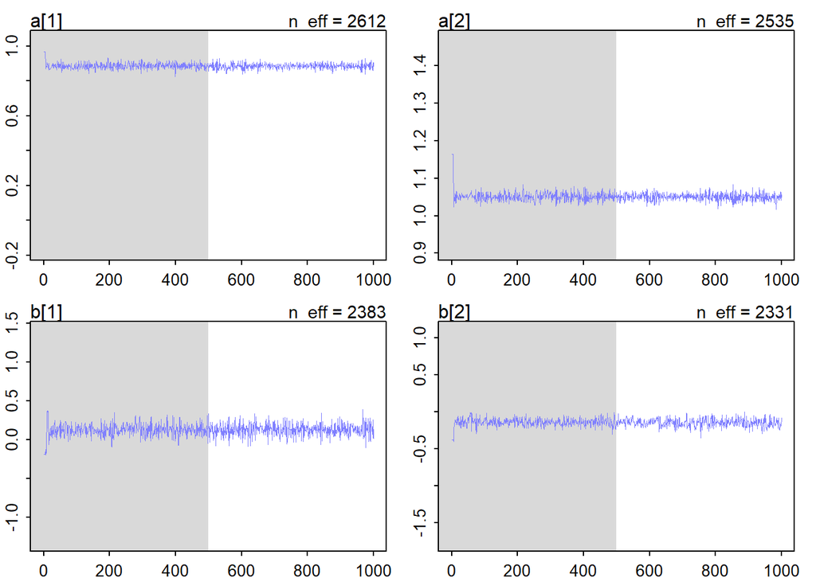

```r
# making trace plot
m2 <- extract.samples(m)
traceplot(m, pars  = c("a[1]", "a[2]", "b[1]", "b[2]"), chains = 1, trim = 1000, n_cols = 2)
```

```r
# somehow, the argument "trim" is not doing it's job, making the y-axis scale too large
```

This is a good trace plot because it is stationary (around a stable mean) and well mixed (no weird spikes, covers a lot of ground).

Now, we create a “bad” model:

```r
# data
y <- c(-1,1)

# a bad model with flat priors
m2 <- ulam(
  alist(
    y ~ dnorm(mu, sigma),
    mu <- alpha,
    alpha ~ dnorm(0, 1000),
    sigma ~ dexp(0.001)
  ),
  data = list(y = y),
  chains = 3,
  cores = 4
)
```

```
## Running MCMC with 3 chains, at most 4 in parallel, with 1 thread(s) per chain...
##
## Chain 1 Iteration:   1 / 1000 [  0%]  (Warmup)
## Chain 1 Iteration: 100 / 1000 [ 10%]  (Warmup)
## Chain 1 Iteration: 200 / 1000 [ 20%]  (Warmup)
## Chain 1 Iteration: 300 / 1000 [ 30%]  (Warmup)
## Chain 1 Iteration: 400 / 1000 [ 40%]  (Warmup)
## Chain 1 Iteration: 500 / 1000 [ 50%]  (Warmup)
## Chain 1 Iteration: 501 / 1000 [ 50%]  (Sampling)
## Chain 1 Iteration: 600 / 1000 [ 60%]  (Sampling)
## Chain 1 Iteration: 700 / 1000 [ 70%]  (Sampling)
## Chain 1 Iteration: 800 / 1000 [ 80%]  (Sampling)
## Chain 1 Iteration: 900 / 1000 [ 90%]  (Sampling)
## Chain 1 Iteration: 1000 / 1000 [100%]  (Sampling)
## Chain 2 Iteration:   1 / 1000 [  0%]  (Warmup)
## Chain 2 Iteration: 100 / 1000 [ 10%]  (Warmup)
## Chain 2 Iteration: 200 / 1000 [ 20%]  (Warmup)
## Chain 2 Iteration: 300 / 1000 [ 30%]  (Warmup)
## Chain 2 Iteration: 400 / 1000 [ 40%]  (Warmup)
## Chain 2 Iteration: 500 / 1000 [ 50%]  (Warmup)
## Chain 2 Iteration: 501 / 1000 [ 50%]  (Sampling)
## Chain 2 Iteration: 600 / 1000 [ 60%]  (Sampling)
## Chain 2 Iteration: 700 / 1000 [ 70%]  (Sampling)
## Chain 2 Iteration: 800 / 1000 [ 80%]  (Sampling)
## Chain 2 Iteration: 900 / 1000 [ 90%]  (Sampling)
## Chain 2 Iteration: 1000 / 1000 [100%]  (Sampling)
## Chain 3 Iteration:   1 / 1000 [  0%]  (Warmup)
## Chain 3 Iteration: 100 / 1000 [ 10%]  (Warmup)
## Chain 3 Iteration: 200 / 1000 [ 20%]  (Warmup)
## Chain 3 Iteration: 300 / 1000 [ 30%]  (Warmup)
## Chain 3 Iteration: 400 / 1000 [ 40%]  (Warmup)
## Chain 3 Iteration: 500 / 1000 [ 50%]  (Warmup)
## Chain 3 Iteration: 501 / 1000 [ 50%]  (Sampling)
## Chain 3 Iteration: 600 / 1000 [ 60%]  (Sampling)
## Chain 3 Iteration: 700 / 1000 [ 70%]  (Sampling)
## Chain 3 Iteration: 800 / 1000 [ 80%]  (Sampling)
## Chain 3 Iteration: 900 / 1000 [ 90%]  (Sampling)
## Chain 3 Iteration: 1000 / 1000 [100%]  (Sampling)
## Chain 1 finished in 0.1 seconds.
## Chain 2 finished in 0.1 seconds.
## Chain 3 finished in 0.1 seconds.
##
## All 3 chains finished successfully.
## Mean chain execution time: 0.1 seconds.
## Total execution time: 0.8 seconds.
```

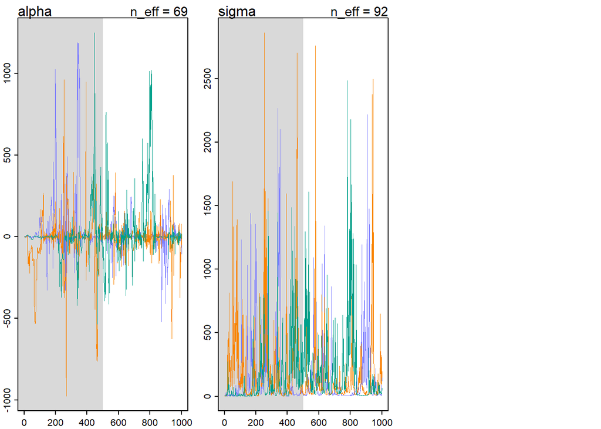

```r
# and a hopefully bad plot:
traceplot(m2)
```

This doesn’t look good - the chains are not “stationary”, the drift around. Also, they’re not well mixed. Instead, we see random spikes into the 1000s.

## Question 7

Now, for the trank plot:

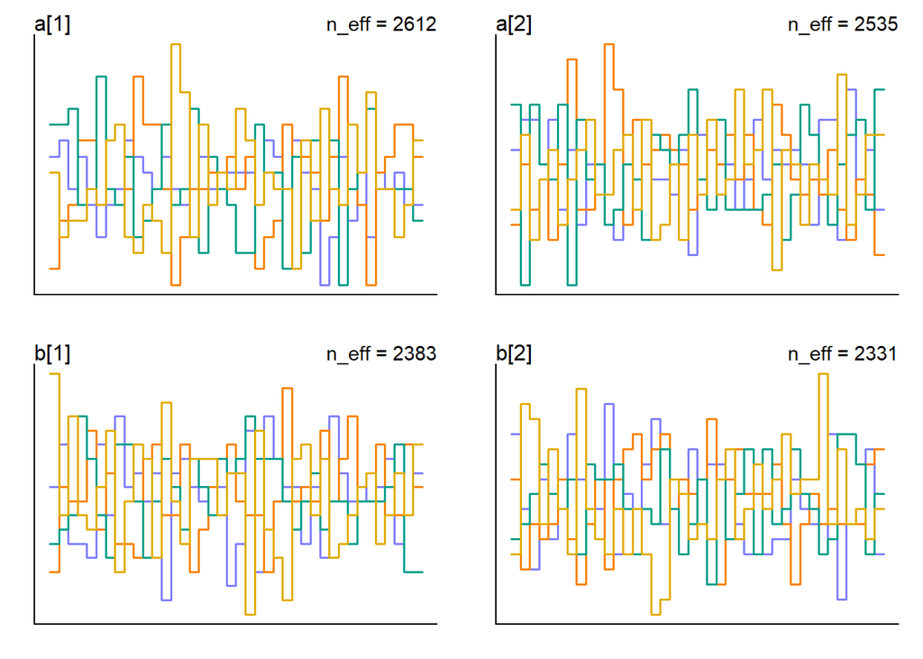

```r
trankplot(m, pars  = c("a[1]", "a[2]", "b[1]", "b[2]"), n_cols = 2)
```

Again, a good plot: The histograms overlap and there is no obvious divergence.

For comparison, a bad trank plot:

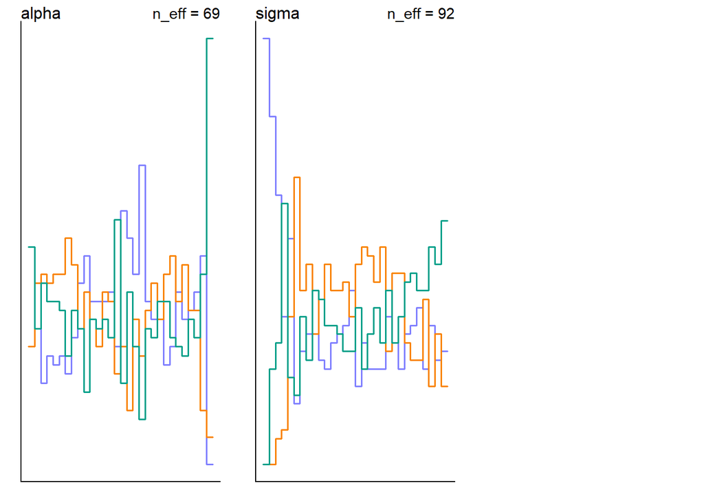

```r
trankplot(m2)
```

Here, we see divergence: For longer periods, one of the chains’ histograms lies above the others.

# Medium Questions

## Question M1

We repeat our terrain model with a uniform prior for sigma:

```r
muni <-
  ulam(
    alist(
      lgdp_std ~ dnorm(mu, sigma),
      mu <- a[cid] + b[cid] * (rugged_std - 0.215),
      a[cid] ~ dnorm(1, 0.1),
      b[cid] ~ dnorm(0, 0.3),
      sigma ~ dunif(0, 1)
    ),
    data = d,
    chains = 4,
    cores = 4
  )
```

```
## Running MCMC with 4 parallel chains, with 1 thread(s) per chain...
##
## Chain 1 Iteration:   1 / 1000 [  0%]  (Warmup)
## Chain 1 Iteration: 100 / 1000 [ 10%]  (Warmup)
## Chain 1 Iteration: 200 / 1000 [ 20%]  (Warmup)
## Chain 1 Iteration: 300 / 1000 [ 30%]  (Warmup)
## Chain 1 Iteration: 400 / 1000 [ 40%]  (Warmup)
## Chain 1 Iteration: 500 / 1000 [ 50%]  (Warmup)
## Chain 1 Iteration: 501 / 1000 [ 50%]  (Sampling)
## Chain 1 Iteration: 600 / 1000 [ 60%]  (Sampling)
## Chain 2 Iteration:   1 / 1000 [  0%]  (Warmup)
## Chain 2 Iteration: 100 / 1000 [ 10%]  (Warmup)
## Chain 2 Iteration: 200 / 1000 [ 20%]  (Warmup)
## Chain 2 Iteration: 300 / 1000 [ 30%]  (Warmup)
## Chain 2 Iteration: 400 / 1000 [ 40%]  (Warmup)
## Chain 2 Iteration: 500 / 1000 [ 50%]  (Warmup)
## Chain 2 Iteration: 501 / 1000 [ 50%]  (Sampling)
## Chain 3 Iteration:   1 / 1000 [  0%]  (Warmup)
## Chain 3 Iteration: 100 / 1000 [ 10%]  (Warmup)
## Chain 3 Iteration: 200 / 1000 [ 20%]  (Warmup)
## Chain 3 Iteration: 300 / 1000 [ 30%]  (Warmup)
## Chain 3 Iteration: 400 / 1000 [ 40%]  (Warmup)
## Chain 4 Iteration:   1 / 1000 [  0%]  (Warmup)
## Chain 4 Iteration: 100 / 1000 [ 10%]  (Warmup)
## Chain 4 Iteration: 200 / 1000 [ 20%]  (Warmup)
## Chain 4 Iteration: 300 / 1000 [ 30%]  (Warmup)
## Chain 1 Iteration: 700 / 1000 [ 70%]  (Sampling)
## Chain 1 Iteration: 800 / 1000 [ 80%]  (Sampling)
## Chain 1 Iteration: 900 / 1000 [ 90%]  (Sampling)
## Chain 1 Iteration: 1000 / 1000 [100%]  (Sampling)
## Chain 1 finished in 0.1 seconds.
## Chain 2 Iteration: 600 / 1000 [ 60%]  (Sampling)
## Chain 2 Iteration: 700 / 1000 [ 70%]  (Sampling)
## Chain 2 Iteration: 800 / 1000 [ 80%]  (Sampling)
## Chain 2 Iteration: 900 / 1000 [ 90%]  (Sampling)
## Chain 2 Iteration: 1000 / 1000 [100%]  (Sampling)
## Chain 2 finished in 0.2 seconds.
## Chain 3 Iteration: 500 / 1000 [ 50%]  (Warmup)
## Chain 3 Iteration: 501 / 1000 [ 50%]  (Sampling)
## Chain 3 Iteration: 600 / 1000 [ 60%]  (Sampling)
## Chain 3 Iteration: 700 / 1000 [ 70%]  (Sampling)
## Chain 3 Iteration: 800 / 1000 [ 80%]  (Sampling)
## Chain 3 Iteration: 900 / 1000 [ 90%]  (Sampling)
## Chain 3 Iteration: 1000 / 1000 [100%]  (Sampling)
## Chain 3 finished in 0.2 seconds.
## Chain 4 Iteration: 400 / 1000 [ 40%]  (Warmup)
## Chain 4 Iteration: 500 / 1000 [ 50%]  (Warmup)
## Chain 4 Iteration: 501 / 1000 [ 50%]  (Sampling)
## Chain 4 Iteration: 600 / 1000 [ 60%]  (Sampling)
## Chain 4 Iteration: 700 / 1000 [ 70%]  (Sampling)
## Chain 4 Iteration: 800 / 1000 [ 80%]  (Sampling)
## Chain 4 Iteration: 900 / 1000 [ 90%]  (Sampling)
## Chain 4 Iteration: 1000 / 1000 [100%]  (Sampling)
## Chain 4 finished in 0.2 seconds.
##
## All 4 chains finished successfully.
## Mean chain execution time: 0.2 seconds.
## Total execution time: 0.4 seconds.
```

```r
precis(m, 2)
```

```
##             mean          sd         5.5%       94.5%    n_eff     Rhat4
## a[1]   0.8864084 0.015874984  0.861395215  0.91081868 2612.106 0.9999438
## a[2]   1.0503224 0.009663707  1.035598900  1.06580660 2534.702 1.0003372
## b[1]   0.1313465 0.077505414  0.002667393  0.25328763 2383.414 1.0004830
## b[2]  -0.1427305 0.054073715 -0.226603585 -0.05746885 2331.042 0.9987401
## sigma  0.1115152 0.006229845  0.102116580  0.12226817 2241.603 0.9992590
```

```r
precis(muni, 2)
```

```
##             mean          sd         5.5%       94.5%    n_eff     Rhat4
## a[1]   0.8860561 0.015889882  0.860847465  0.91169865 2165.790 0.9998568
## a[2]   1.0505939 0.010646535  1.033676150  1.06741055 2714.441 0.9993606
## b[1]   0.1299954 0.073870043  0.009022421  0.24429266 1966.394 1.0010961
## b[2]  -0.1428088 0.055833245 -0.231272805 -0.05614196 2307.088 0.9996441
## sigma  0.1115237 0.006082231  0.102416945  0.12143182 2475.479 1.0011437
```

It does not have an effect on the posterior distribution of sigma. Considering how many samples we have, the prior for sigma doesn’t seem to matter much, as it is easily overcome. It also might help that sigma is constrained to positive values.

## Question M2

Now, we change the prior of b[cid]:

```r
mb <-
  ulam(
    alist(
      lgdp_std ~ dnorm(mu, sigma),
      mu <- a[cid] + b[cid] * (rugged_std - 0.215),
      a[cid] ~ dnorm(1, 0.1),
      b[cid] ~ dexp(0.3),
      sigma ~ dexp(1)
    ),
    data = d,
    chains = 4,
    cores = 4
  )
```

```
## Running MCMC with 4 parallel chains, with 1 thread(s) per chain...
##
## Chain 1 Iteration:   1 / 1000 [  0%]  (Warmup)
## Chain 1 Iteration: 100 / 1000 [ 10%]  (Warmup)
## Chain 2 Iteration:   1 / 1000 [  0%]  (Warmup)
## Chain 2 Iteration: 100 / 1000 [ 10%]  (Warmup)
## Chain 2 Iteration: 200 / 1000 [ 20%]  (Warmup)
## Chain 3 Iteration:   1 / 1000 [  0%]  (Warmup)
## Chain 3 Iteration: 100 / 1000 [ 10%]  (Warmup)
## Chain 4 Iteration:   1 / 1000 [  0%]  (Warmup)
## Chain 4 Iteration: 100 / 1000 [ 10%]  (Warmup)
## Chain 1 Iteration: 200 / 1000 [ 20%]  (Warmup)
## Chain 1 Iteration: 300 / 1000 [ 30%]  (Warmup)
## Chain 1 Iteration: 400 / 1000 [ 40%]  (Warmup)
## Chain 1 Iteration: 500 / 1000 [ 50%]  (Warmup)
## Chain 1 Iteration: 501 / 1000 [ 50%]  (Sampling)
## Chain 1 Iteration: 600 / 1000 [ 60%]  (Sampling)
## Chain 1 Iteration: 700 / 1000 [ 70%]  (Sampling)
## Chain 1 Iteration: 800 / 1000 [ 80%]  (Sampling)
## Chain 1 Iteration: 900 / 1000 [ 90%]  (Sampling)
## Chain 1 Iteration: 1000 / 1000 [100%]  (Sampling)
## Chain 1 finished in 0.2 seconds.
## Chain 2 Iteration: 300 / 1000 [ 30%]  (Warmup)
## Chain 2 Iteration: 400 / 1000 [ 40%]  (Warmup)
## Chain 2 Iteration: 500 / 1000 [ 50%]  (Warmup)
## Chain 2 Iteration: 501 / 1000 [ 50%]  (Sampling)
## Chain 2 Iteration: 600 / 1000 [ 60%]  (Sampling)
## Chain 2 Iteration: 700 / 1000 [ 70%]  (Sampling)
## Chain 2 Iteration: 800 / 1000 [ 80%]  (Sampling)
## Chain 2 Iteration: 900 / 1000 [ 90%]  (Sampling)
## Chain 2 Iteration: 1000 / 1000 [100%]  (Sampling)
## Chain 2 finished in 0.2 seconds.
## Chain 3 Iteration: 200 / 1000 [ 20%]  (Warmup)
## Chain 3 Iteration: 300 / 1000 [ 30%]  (Warmup)
## Chain 3 Iteration: 400 / 1000 [ 40%]  (Warmup)
## Chain 3 Iteration: 500 / 1000 [ 50%]  (Warmup)
## Chain 3 Iteration: 501 / 1000 [ 50%]  (Sampling)
## Chain 3 Iteration: 600 / 1000 [ 60%]  (Sampling)
## Chain 3 Iteration: 700 / 1000 [ 70%]  (Sampling)
## Chain 3 Iteration: 800 / 1000 [ 80%]  (Sampling)
## Chain 3 Iteration: 900 / 1000 [ 90%]  (Sampling)
## Chain 3 Iteration: 1000 / 1000 [100%]  (Sampling)
## Chain 3 finished in 0.2 seconds.
## Chain 4 Iteration: 200 / 1000 [ 20%]  (Warmup)
## Chain 4 Iteration: 300 / 1000 [ 30%]  (Warmup)
## Chain 4 Iteration: 400 / 1000 [ 40%]  (Warmup)
## Chain 4 Iteration: 500 / 1000 [ 50%]  (Warmup)
## Chain 4 Iteration: 501 / 1000 [ 50%]  (Sampling)
## Chain 4 Iteration: 600 / 1000 [ 60%]  (Sampling)
## Chain 4 Iteration: 700 / 1000 [ 70%]  (Sampling)
## Chain 4 Iteration: 800 / 1000 [ 80%]  (Sampling)
## Chain 4 Iteration: 900 / 1000 [ 90%]  (Sampling)
## Chain 4 Iteration: 1000 / 1000 [100%]  (Sampling)
## Chain 4 finished in 0.2 seconds.
##
## All 4 chains finished successfully.
## Mean chain execution time: 0.2 seconds.
## Total execution time: 0.4 seconds.
```

```r
precis(mb, 2)
```

```
##             mean          sd        5.5%      94.5%     n_eff     Rhat4
## a[1]  0.88746798 0.016355635 0.862178655 0.91372579 1986.0751 1.0005119
## a[2]  1.04800676 0.010484914 1.030916150 1.06440770 2036.8983 0.9987308
## b[1]  0.14248313 0.075238304 0.023864051 0.26722447  590.9843 1.0087493
## b[2]  0.01897907 0.017916239 0.001151852 0.05256718 2332.7540 0.9992043
## sigma 0.11419234 0.006299071 0.104476120 0.12477300 1610.4463 0.9992230
```

The new prior changed the posterior distribution for both betas, but especially the one for countries outside of Africa; its mean decreases to almost zero. We also see that, for most parameters, the n_eff value has decreased noticeably.

The reason for the change in b[2] is that with the exponential prior distribution we gave it, we effectively limited it to positive values. This explains why b[1] (which should turn out with a mean of ~0.15) remains unchanged with our new prior, and why b[2] (which should have a mean around -0.14) is effectively zero: It “tries” to approach the negative value the samples suggest, but our exponential prior keeps it stuck in the positives.

On the other hand, I’m not why n_eff decreased so much. Maybe the (quite informative but) wrong prior removes some of the autocorrelation that makes n_eff larger then the actual # of samples in good models?

## Question M3

I assume “be sure to use the same number of sampling iterations” refers to the *real samples*, not the “iter” value (total samples.) I’ll therefore try different values of warmup samples (default was 500) and adjust “iter” so that the number of real samples remains 500.

```r
# let's try 100 warmup samples
m100 <- update(m, warmup = 100, iter = 600)
```

```
## Running MCMC with 4 parallel chains, with 1 thread(s) per chain...
##
## Chain 1 WARNING: There aren't enough warmup iterations to fit the
## Chain 1          three stages of adaptation as currently configured.
## Chain 1          Reducing each adaptation stage to 15%/75%/10% of
## Chain 1          the given number of warmup iterations:
## Chain 1            init_buffer = 15
## Chain 1            adapt_window = 75
## Chain 1            term_buffer = 10
## Chain 1 Iteration:   1 / 600 [  0%]  (Warmup)
## Chain 1 Iteration: 100 / 600 [ 16%]  (Warmup)
## Chain 1 Iteration: 101 / 600 [ 16%]  (Sampling)
## Chain 1 Iteration: 200 / 600 [ 33%]  (Sampling)
## Chain 1 Iteration: 300 / 600 [ 50%]  (Sampling)
## Chain 1 Iteration: 400 / 600 [ 66%]  (Sampling)
## Chain 1 Iteration: 500 / 600 [ 83%]  (Sampling)
## Chain 1 Iteration: 600 / 600 [100%]  (Sampling)
## Chain 2 WARNING: There aren't enough warmup iterations to fit the
## Chain 2          three stages of adaptation as currently configured.
## Chain 2          Reducing each adaptation stage to 15%/75%/10% of
## Chain 2          the given number of warmup iterations:
## Chain 2            init_buffer = 15
## Chain 2            adapt_window = 75
## Chain 2            term_buffer = 10
## Chain 2 Iteration:   1 / 600 [  0%]  (Warmup)
## Chain 2 Iteration: 100 / 600 [ 16%]  (Warmup)
## Chain 2 Iteration: 101 / 600 [ 16%]  (Sampling)
## Chain 2 Iteration: 200 / 600 [ 33%]  (Sampling)
## Chain 2 Iteration: 300 / 600 [ 50%]  (Sampling)
## Chain 2 Iteration: 400 / 600 [ 66%]  (Sampling)
## Chain 2 Iteration: 500 / 600 [ 83%]  (Sampling)
## Chain 3 WARNING: There aren't enough warmup iterations to fit the
## Chain 3          three stages of adaptation as currently configured.
## Chain 3          Reducing each adaptation stage to 15%/75%/10% of
## Chain 3          the given number of warmup iterations:
## Chain 3            init_buffer = 15
## Chain 3            adapt_window = 75
## Chain 3            term_buffer = 10
## Chain 3 Iteration:   1 / 600 [  0%]  (Warmup)
## Chain 3 Iteration: 100 / 600 [ 16%]  (Warmup)
```

[output cut: 15 more lines]

```
## Chain 4 Iteration: 300 / 600 [ 50%]  (Sampling)
## Chain 4 Iteration: 400 / 600 [ 66%]  (Sampling)
## Chain 1 finished in 0.1 seconds.
## Chain 2 Iteration: 600 / 600 [100%]  (Sampling)
## Chain 2 finished in 0.1 seconds.
## Chain 3 Iteration: 500 / 600 [ 83%]  (Sampling)
## Chain 3 Iteration: 600 / 600 [100%]  (Sampling)
## Chain 3 finished in 0.1 seconds.
## Chain 4 Iteration: 500 / 600 [ 83%]  (Sampling)
## Chain 4 Iteration: 600 / 600 [100%]  (Sampling)
## Chain 4 finished in 0.1 seconds.
##
## All 4 chains finished successfully.
## Mean chain execution time: 0.1 seconds.
## Total execution time: 0.9 seconds.
```

```r
m200 <- update(m, warmup = 200, iter = 700)
```

```
## Running MCMC with 4 parallel chains, with 1 thread(s) per chain...
##
## Chain 1 Iteration:   1 / 700 [  0%]  (Warmup)
## Chain 1 Iteration: 100 / 700 [ 14%]  (Warmup)
## Chain 1 Iteration: 200 / 700 [ 28%]  (Warmup)
## Chain 1 Iteration: 201 / 700 [ 28%]  (Sampling)
## Chain 1 Iteration: 300 / 700 [ 42%]  (Sampling)
## Chain 1 Iteration: 400 / 700 [ 57%]  (Sampling)
## Chain 1 Iteration: 500 / 700 [ 71%]  (Sampling)
## Chain 1 Iteration: 600 / 700 [ 85%]  (Sampling)
## Chain 1 Iteration: 700 / 700 [100%]  (Sampling)
## Chain 2 Iteration:   1 / 700 [  0%]  (Warmup)
## Chain 2 Iteration: 100 / 700 [ 14%]  (Warmup)
## Chain 2 Iteration: 200 / 700 [ 28%]  (Warmup)
## Chain 2 Iteration: 201 / 700 [ 28%]  (Sampling)
## Chain 2 Iteration: 300 / 700 [ 42%]  (Sampling)
## Chain 2 Iteration: 400 / 700 [ 57%]  (Sampling)
## Chain 2 Iteration: 500 / 700 [ 71%]  (Sampling)
## Chain 2 Iteration: 600 / 700 [ 85%]  (Sampling)
## Chain 2 Iteration: 700 / 700 [100%]  (Sampling)
## Chain 3 Iteration:   1 / 700 [  0%]  (Warmup)
## Chain 3 Iteration: 100 / 700 [ 14%]  (Warmup)
## Chain 3 Iteration: 200 / 700 [ 28%]  (Warmup)
## Chain 3 Iteration: 201 / 700 [ 28%]  (Sampling)
## Chain 3 Iteration: 300 / 700 [ 42%]  (Sampling)
## Chain 3 Iteration: 400 / 700 [ 57%]  (Sampling)
## Chain 3 Iteration: 500 / 700 [ 71%]  (Sampling)
## Chain 3 Iteration: 600 / 700 [ 85%]  (Sampling)
## Chain 3 Iteration: 700 / 700 [100%]  (Sampling)
## Chain 4 Iteration:   1 / 700 [  0%]  (Warmup)
## Chain 4 Iteration: 100 / 700 [ 14%]  (Warmup)
## Chain 4 Iteration: 200 / 700 [ 28%]  (Warmup)
## Chain 4 Iteration: 201 / 700 [ 28%]  (Sampling)
## Chain 4 Iteration: 300 / 700 [ 42%]  (Sampling)
## Chain 4 Iteration: 400 / 700 [ 57%]  (Sampling)
## Chain 4 Iteration: 500 / 700 [ 71%]  (Sampling)
## Chain 4 Iteration: 600 / 700 [ 85%]  (Sampling)
## Chain 4 Iteration: 700 / 700 [100%]  (Sampling)
## Chain 1 finished in 0.1 seconds.
## Chain 2 finished in 0.1 seconds.
## Chain 3 finished in 0.1 seconds.
## Chain 4 finished in 0.1 seconds.
##
## All 4 chains finished successfully.
## Mean chain execution time: 0.1 seconds.
## Total execution time: 0.4 seconds.
```

```r
m300 <- update(m, warmup = 300, iter = 800)
```

```
## Running MCMC with 4 parallel chains, with 1 thread(s) per chain...
##
## Chain 1 Iteration:   1 / 800 [  0%]  (Warmup)
## Chain 1 Iteration: 100 / 800 [ 12%]  (Warmup)
## Chain 1 Iteration: 200 / 800 [ 25%]  (Warmup)
## Chain 1 Iteration: 300 / 800 [ 37%]  (Warmup)
## Chain 1 Iteration: 301 / 800 [ 37%]  (Sampling)
## Chain 1 Iteration: 400 / 800 [ 50%]  (Sampling)
## Chain 1 Iteration: 500 / 800 [ 62%]  (Sampling)
## Chain 1 Iteration: 600 / 800 [ 75%]  (Sampling)
## Chain 1 Iteration: 700 / 800 [ 87%]  (Sampling)
## Chain 1 Iteration: 800 / 800 [100%]  (Sampling)
## Chain 2 Iteration:   1 / 800 [  0%]  (Warmup)
## Chain 2 Iteration: 100 / 800 [ 12%]  (Warmup)
## Chain 2 Iteration: 200 / 800 [ 25%]  (Warmup)
## Chain 2 Iteration: 300 / 800 [ 37%]  (Warmup)
## Chain 2 Iteration: 301 / 800 [ 37%]  (Sampling)
## Chain 2 Iteration: 400 / 800 [ 50%]  (Sampling)
## Chain 2 Iteration: 500 / 800 [ 62%]  (Sampling)
## Chain 2 Iteration: 600 / 800 [ 75%]  (Sampling)
## Chain 2 Iteration: 700 / 800 [ 87%]  (Sampling)
## Chain 2 Iteration: 800 / 800 [100%]  (Sampling)
## Chain 3 Iteration:   1 / 800 [  0%]  (Warmup)
## Chain 3 Iteration: 100 / 800 [ 12%]  (Warmup)
## Chain 3 Iteration: 200 / 800 [ 25%]  (Warmup)
## Chain 3 Iteration: 300 / 800 [ 37%]  (Warmup)
## Chain 3 Iteration: 301 / 800 [ 37%]  (Sampling)
## Chain 3 Iteration: 400 / 800 [ 50%]  (Sampling)
## Chain 3 Iteration: 500 / 800 [ 62%]  (Sampling)
## Chain 3 Iteration: 600 / 800 [ 75%]  (Sampling)
## Chain 3 Iteration: 700 / 800 [ 87%]  (Sampling)
## Chain 3 Iteration: 800 / 800 [100%]  (Sampling)
## Chain 4 Iteration:   1 / 800 [  0%]  (Warmup)
## Chain 4 Iteration: 100 / 800 [ 12%]  (Warmup)
## Chain 4 Iteration: 200 / 800 [ 25%]  (Warmup)
## Chain 4 Iteration: 300 / 800 [ 37%]  (Warmup)
## Chain 4 Iteration: 301 / 800 [ 37%]  (Sampling)
## Chain 4 Iteration: 400 / 800 [ 50%]  (Sampling)
## Chain 4 Iteration: 500 / 800 [ 62%]  (Sampling)
## Chain 4 Iteration: 600 / 800 [ 75%]  (Sampling)
## Chain 4 Iteration: 700 / 800 [ 87%]  (Sampling)
## Chain 4 Iteration: 800 / 800 [100%]  (Sampling)
## Chain 1 finished in 0.1 seconds.
## Chain 2 finished in 0.1 seconds.
## Chain 3 finished in 0.1 seconds.
## Chain 4 finished in 0.1 seconds.
##
## All 4 chains finished successfully.
## Mean chain execution time: 0.1 seconds.
## Total execution time: 0.4 seconds.
```

```r
precis(m, 2)
```

```
##             mean          sd         5.5%       94.5%    n_eff     Rhat4
## a[1]   0.8864084 0.015874984  0.861395215  0.91081868 2612.106 0.9999438
## a[2]   1.0503224 0.009663707  1.035598900  1.06580660 2534.702 1.0003372
## b[1]   0.1313465 0.077505414  0.002667393  0.25328763 2383.414 1.0004830
## b[2]  -0.1427305 0.054073715 -0.226603585 -0.05746885 2331.042 0.9987401
## sigma  0.1115152 0.006229845  0.102116580  0.12226817 2241.603 0.9992590
```

```r
precis(m100, 2)
```

```
##             mean          sd        5.5%       94.5%     n_eff     Rhat4
## a[1]   0.8866764 0.016844413  0.85965637  0.91315388 2272.6446 1.0003688
## a[2]   1.0503581 0.009910161  1.03451285  1.06582715 2390.3980 0.9995274
## b[1]   0.1322586 0.074472172  0.01105752  0.25038871  881.7957 1.0058774
## b[2]  -0.1390507 0.055686684 -0.22597468 -0.04850659 1142.9976 1.0014610
## sigma  0.1115886 0.006165485  0.10216507  0.12157706 1016.5181 1.0044247
```

```r
precis(m200, 2)
```

```
##             mean          sd        5.5%       94.5%    n_eff     Rhat4
## a[1]   0.8865585 0.015950827  0.86103440  0.91184187 2523.024 0.9989854
## a[2]   1.0508788 0.010128020  1.03388890  1.06671055 3081.782 0.9990888
## b[1]   0.1306740 0.075953562  0.01066186  0.25116027 1935.435 0.9998396
## b[2]  -0.1419259 0.056142928 -0.23040952 -0.04935619 1546.265 1.0015983
## sigma  0.1113752 0.006299423  0.10172457  0.12209250 2024.403 1.0000192
```

```r
precis(m300, 2)
```

```
##             mean          sd        5.5%       94.5%    n_eff     Rhat4
## a[1]   0.8863700 0.015030930  0.86286774  0.91032295 2237.798 0.9991144
## a[2]   1.0507181 0.009875946  1.03558780  1.06606055 3230.912 0.9983325
## b[1]   0.1309208 0.073314128  0.01212355  0.24902672 2519.604 1.0003820
## b[2]  -0.1438935 0.058539268 -0.23888779 -0.04991815 2828.608 1.0000106
## sigma  0.1113819 0.005887583  0.10225534  0.12146297 2389.422 1.0002774
```

With our four chains, in the initial model we had 2000 real samples. The number of effective samples (n_eff) was higher than that for all parameters, as it should be.

With only 100 warmup samples (and still 2000 real samples), n_eff falls significantly below 2000 for many of the parameters.

At 200 warmup samples, only two parameters have n_eff values below 2000, and the difference is less severe.